# Introduction

# Linear Regression

```python
X = data[['Interest Rate','USD/TRY']]
y = data['Istanbul House Price']
```

```python
from sklearn.model_selection import train_test_split
```

```python
X_train, X_test, y_train, y_test = train_test_split(X, y, test_size=0.4, random_state=101)
```

```python
from sklearn.linear_model import LinearRegression
```

```python
lm = LinearRegression()
train_test_split
```

```
<function sklearn.model_selection._split.train_test_split(*arrays, **options)>
```

```python
lm.fit(X_train,y_train)
```

```
LinearRegression(copy_X=True, fit_intercept=True, n_jobs=None, normalize=False)
```

```python
coeff_df = pd.DataFrame(lm.coef_,X.columns,columns=['Coefficient'])
coeff_df
```

|  | Coefficient |
| --- | --- |
| Interest Rate | -242.392806 |
| USD/TRY | 1602.114977 |

```python
predictions = lm.predict(X_test)
```

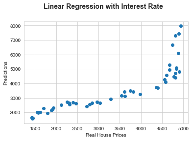

```python
fig = plt.figure()
fig.suptitle('Linear Regression with Interest Rate', fontsize=14, fontweight='bold')
plt.scatter(y_test,predictions)
ax = fig.add_subplot(111)
fig.subplots_adjust(top=0.85)

ax.set_xlabel('Real House Prices')
ax.set_ylabel('Predictions')
```

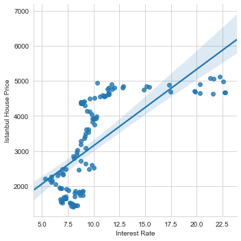

```python
sns.lmplot(x='Interest Rate',y='Istanbul House Price',data=data)
```

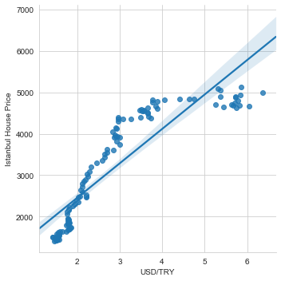

```python
sns.lmplot(x='USD/TRY',y='Istanbul House Price',data=data)
```

```python
from sklearn import metrics
print('MAE:', metrics.mean_absolute_error(y_test, predictions))
print('MSE:', metrics.mean_squared_error(y_test, predictions))
print('RMSE:', np.sqrt(metrics.mean_squared_error(y_test, predictions)))
```

```
MAE: 526.633053546041
MSE: 683158.473009867
RMSE: 826.5340120103147
```

# Analysis on Linear Regression

When we put these data into multiple linear regression model, we get the following equation House Prices = -242.39*Interest Rate + 1602*USD/TRY. That is quite meaningful because we expected to exchange rate has positive effect whereas interest rate has reverse effect on house prices. When we check the predictions and observations we, again, get similar results. When house prices are below 4000TL, the predictions are almost reasonable however, when the house prices are above 4000TL the model predicts them to be much higher than they really are and that is because, as mentioned above, the exchange rate increases rapidly but house prices can’t follow this increment. Finally, when we check the simple linear regression plot of exchange rate against house prices, even though the model undervalue the house prices below 4500TL, it is a somehow good exploratory variable and the confidence interval is smaller. When house prices are above 4500Tl the model overvalue the house prices and the confidence interval is much wider. We also see that interest rate is not a good estimator of house prices as exchange rate.

# Conclusion

The USD/TRY exchange rate is highly correlated with the house prices in Istanbul and very good estimator of it until 2018. Because of the coup attempt and economical unreliability in Turkey’s economy after 2018 (preliminary knowledge), the correlation between exchange rate and house prices decrease and even starts to give highly unreliable predictions. After 2019, when the exchange rate is stabilized, the house price starts to increase steadily but slowly. The interest rate is also effective in house prices as expected but not as much as exchange rate. It is reverse effective on house prices and we can see its affect when wee look at 2013. The interest rate decreases rapidly and there is a rapid increase in house prices. Also, in the beginning of 2014 there is a rapid increase in interest rate and wee see that the increase in house prices slows down and there is the first evidence of small decrease in house prices.